# Customer Satisfaction

Daniel ten Wolde

12/9/2019

## Overall Customer Review Scores

[interactive chart not shown]

As can be seen from the plot shown above, it is clear Alaska Airlines and Delta Air Lines have the highest overall customer reviews. On the lower end we find Frontier Airlines. It seems that Frontier customers fly at a lower cost, but this also impacts their satisfaction. Thus we might conclude that a cheaper flight is not always worth it. The difference becomes even more apparent if we take a look at the WiFi and In-Flight Entertainment reviews of all airlines.

[interactive chart not shown]

Here we see that Frontier Airlines is by far the worst scoring airline with a review score of 34 for In-Flight Entertainment and 29 for WiFi. However these scores can be explained by the business philosphy that Frontier Airlines has adopted. They want to offer the cheapest flights possible and thus try to cut down on things such as In-Flight Entertainment and WiFi.

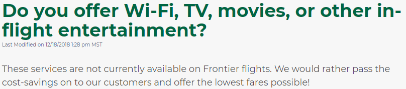

Comment from Frontier Airlines, source: https://faq.flyfrontier.com/help/do-you-offer-wi-fi-tv-movies-or-other-in-flight-entertainment

Delta and Alaska have the highest score. Delta offers free Wifi (https://www.delta.com/content/www/en_US/traveling-with-us/onboard-services/delta-studio/in-flight-wi-fi.html) and it seems to do them well in the review scores.

## Boarding and Deplaning reviews

[interactive chart not shown]

With Boarding and Deplaning we see a similar trend where Alaska Airlines and Delta Air Lines are at the top. Next to that we also see Frontier Airlines having the lowest score, again. We will look into the departure and arrival delays to see if we can spot the same trend. We might expect frontier to have more delay on average since that would justify the lower review scores.

[interactive chart not shown]

We can see from the boxplot shown above that, on average, Frontier Airlines has more departure delay than other airlines. However the majority of departure delays are within 14 minutes of the scheduled departure time and thus the actual delay is relatively small. American Airlines, Delta Air Lines and United Airlines are more consistent in this category since their upper and lower fences are not as far apart, indicating a smaller spread in departure delays. Alaska Airlines is somewhere in between these groups.

[interactive chart not shown]

Looking at the arrival delay we see a similar trend as to the departure delay with Frontier Airlines scoring the worst together. Interesting is that Alaska Airlines scores similar to Frontier Airlines in this category. All major airlines have a similar score.